# SALIENCY MAP

## Table of Contents

1. Introduction
2. Setup
3. Load a pre-trained model and an example image
4. Compute saliency and visualization
5. References

## **1. Introduction**

In this notebook, we explore the concept of saliency maps in deep learning. A saliency map is an image that highlights the region of interest in our computer vision model, providing insight into how the model "sees" and interprets the input.

The primary goal is to generate and visualize saliency maps for a given image using a pretrained convolutional neural network (CNN). This helps us better understand model interpretability, identify potential biases, and validate whether the model is focusing on the correct features.

We'll walk through the following steps:

- Load a pretrained image classification model.
- Pass an input image through the model.
- Compute gradients of the target class with respect to the input image.
- Visualize the resulting saliency map.

By the end of this notebook, you'll have a working pipeline to generate saliency maps and a practical understanding of how they aid in model interpretability.

## **2. Setup**

```python
import torch
from torchvision import models, transforms
from PIL import Image, ImageOps
import matplotlib.pyplot as plt
import numpy as np
```

## **3. Load a pre-trained model and an example image**

As model, we will use Resnet50.

ResNet50 is a 50-layer deep convolutional neural network from the Residual Networks family. It's designed to train very deep networks effectively by using residual (skip) connections that help mitigate the vanishing gradient problem.

Key points:

- Contains 50 layers with learnable weights.
- Uses bottleneck blocks: each residual block consists of 3 layers (1×1, 3×3, 1×1 conv).
- Trained on ImageNet (1000 classes) when using pretrained=True.
- Input size: 3×224×224 RGB images.

```python
# Load model
model = models.resnet50(pretrained=True).eval()
```

```python
from torchvision import models
from torchinfo import summary

model = models.resnet50(pretrained=True).eval()

# Show model summary
summary(model, input_size=(1, 3, 224, 224))
```

```
==========================================================================================
Layer (type:depth-idx)                   Output Shape              Param #
==========================================================================================
ResNet                                   [1, 1000]                 --
├─Conv2d: 1-1                            [1, 64, 112, 112]         9,408
├─BatchNorm2d: 1-2                       [1, 64, 112, 112]         128
├─ReLU: 1-3                              [1, 64, 112, 112]         --
├─MaxPool2d: 1-4                         [1, 64, 56, 56]           --
├─Sequential: 1-5                        [1, 256, 56, 56]          --
│    └─Bottleneck: 2-1                   [1, 256, 56, 56]          --
│    │    └─Conv2d: 3-1                  [1, 64, 56, 56]           4,096
│    │    └─BatchNorm2d: 3-2             [1, 64, 56, 56]           128
│    │    └─ReLU: 3-3                    [1, 64, 56, 56]           --
│    │    └─Conv2d: 3-4                  [1, 64, 56, 56]           36,864
│    │    └─BatchNorm2d: 3-5             [1, 64, 56, 56]           128
│    │    └─ReLU: 3-6                    [1, 64, 56, 56]           --
│    │    └─Conv2d: 3-7                  [1, 256, 56, 56]          16,384
│    │    └─BatchNorm2d: 3-8             [1, 256, 56, 56]          512
│    │    └─Sequential: 3-9              [1, 256, 56, 56]          16,896
│    │    └─ReLU: 3-10                   [1, 256, 56, 56]          --
│    └─Bottleneck: 2-2                   [1, 256, 56, 56]          --
│    │    └─Conv2d: 3-11                 [1, 64, 56, 56]           16,384
│    │    └─BatchNorm2d: 3-12            [1, 64, 56, 56]           128
│    │    └─ReLU: 3-13                   [1, 64, 56, 56]           --
│    │    └─Conv2d: 3-14                 [1, 64, 56, 56]           36,864
│    │    └─BatchNorm2d: 3-15            [1, 64, 56, 56]           128
│    │    └─ReLU: 3-16                   [1, 64, 56, 56]           --
│    │    └─Conv2d: 3-17                 [1, 256, 56, 56]          16,384
│    │    └─BatchNorm2d: 3-18            [1, 256, 56, 56]          512
│    │    └─ReLU: 3-19                   [1, 256, 56, 56]          --
│    └─Bottleneck: 2-3                   [1, 256, 56, 56]          --
│    │    └─Conv2d: 3-20                 [1, 64, 56, 56]           16,384
│    │    └─BatchNorm2d: 3-21            [1, 64, 56, 56]           128
│    │    └─ReLU: 3-22                   [1, 64, 56, 56]           --
│    │    └─Conv2d: 3-23                 [1, 64, 56, 56]           36,864
│    │    └─BatchNorm2d: 3-24            [1, 64, 56, 56]           128
│    │    └─ReLU: 3-25                   [1, 64, 56, 56]           --
│    │    └─Conv2d: 3-26                 [1, 256, 56, 56]          16,384
│    │    └─BatchNorm2d: 3-27            [1, 256, 56, 56]          512
│    │    └─ReLU: 3-28                   [1, 256, 56, 56]          --
```

[output cut: 134 more lines]

```
│    │    └─BatchNorm2d: 3-147           [1, 2048, 7, 7]           4,096
│    │    └─ReLU: 3-148                  [1, 2048, 7, 7]           --
├─AdaptiveAvgPool2d: 1-9                 [1, 2048, 1, 1]           --
├─Linear: 1-10                           [1, 1000]                 2,049,000
==========================================================================================
Total params: 25,557,032
Trainable params: 25,557,032
Non-trainable params: 0
Total mult-adds (G): 4.09
==========================================================================================
Input size (MB): 0.60
Forward/backward pass size (MB): 177.83
Params size (MB): 102.23
Estimated Total Size (MB): 280.66
==========================================================================================
```

Note that the final layer is a fully connected (nn.Linear) layer with 1000 outputs (for the 1000 ImageNet classes).

The output is raw logits, not probabilities.

Next, let's load an image:

```python
# Load an image
!wget -O image.jpg https://cdn.pixabay.com/photo/2018/02/27/14/11/the-pacific-ocean-3185553_960_720.jpg
```

```
--2025-06-03 17:30:27--  https://cdn.pixabay.com/photo/2018/02/27/14/11/the-pacific-ocean-3185553_960_720.jpg
Resolviendo cdn.pixabay.com (cdn.pixabay.com)... 104.18.40.96, 172.64.147.160, 2606:4700:4400::ac40:93a0, ...
Conectando con cdn.pixabay.com (cdn.pixabay.com)[104.18.40.96]:443... conectado.
Petición HTTP enviada, esperando respuesta... 200 OK
Longitud: 215472 (210K) [image/jpeg]
Guardando como: ‘image.jpg’

image.jpg           100%[===================>] 210,42K  --.-KB/s    en 0,03s

2025-06-03 17:30:28 (6,50 MB/s) - ‘image.jpg’ guardado [215472/215472]
```

ResNet50 expects input images to be in RGB format and resized to 224×224 pixels, with normalization using the ImageNet dataset statistics (mean and standard deviation). To prepare our image accordingly, we define the following preprocessing function, which resizes, normalizes, and converts the image into a tensor suitable for model input and gradient-based operations like saliency maps.

```python
# -----------------------------
# Preprocess the input image
# -----------------------------
def preprocess_image(img_path):
    """
    Loads and preprocesses an image for a CNN model (e.g., ResNet).

    Args:
        img_path (str): Path to the image file.

    Returns:
        tuple:
            - img (PIL.Image): Original RGB image.
            - tensor (torch.Tensor): Preprocessed image tensor with shape (1, 3, 224, 224),
              with gradients enabled for saliency computation.
    """

    # Define a transformation pipeline:
    # 1. Resize the image to 224x224 (standard input size for many pretrained models)
    # 2. Convert it to a PyTorch tensor (values scaled to [0, 1])
    # 3. Normalize using ImageNet mean and std to match model training stats
    transform = transforms.Compose([
        transforms.Resize((224, 224)),  # Resize to fixed dimensions
        transforms.ToTensor(),  # Convert to tensor and scale to [0,1]
        transforms.Normalize(
            mean=[0.485, 0.456, 0.406],  # ImageNet mean
            std=[0.229, 0.224, 0.225]    # ImageNet std
        )
    ])

    # Open the image and convert to RGB (ensures 3 channels)
    img = Image.open(img_path).convert('RGB')

    # Apply transformations and add batch dimension with unsqueeze(0)
    tensor = transform(img).unsqueeze(0)

    # Enable gradient tracking for saliency map computation
    return img, tensor.requires_grad_()
```

## **4. Compute saliency and visualization**

```python
# -----------------------------
# Saliency computation
# -----------------------------
def compute_saliency(model, input_tensor, class_idx=None):
    """
    Computes the saliency map for a given input image and model.

    Args:
        model (torch.nn.Module): Pretrained image classification model.
        input_tensor (torch.Tensor): Input image tensor of shape (1, C, H, W) with requires_grad enabled.
        class_idx (int, optional): Index of the target class. If None, the predicted class is used.

    Returns:
        tuple: (saliency_map (np.ndarray), class_idx (int))
            - saliency_map: 2D numpy array representing the normalized saliency map.
            - class_idx: Class index used to compute the saliency.
    """
    model.eval()  # set model to evaluation mode
    input_tensor.requires_grad_()  # enable gradient tracking for the input

    output = model(input_tensor)  # forward pass

    # Use predicted class if none provided
    if class_idx is None:
        class_idx = output.argmax(dim=1).item()

    score = output[0, class_idx]  # get the score for the target class
    model.zero_grad()  # clear previous gradients
    score.backward()  # backpropagate to compute gradients w.r.t. input

    # Compute absolute value of the gradients and take the maximum over the channels
    saliency = input_tensor.grad.abs().squeeze().cpu()
    saliency, _ = torch.max(saliency, dim=0)

    # Normalize the saliency map to [0, 1]
    saliency -= saliency.min()
    saliency /= saliency.max() + 1e-8

    return saliency.numpy(), class_idx
```

For visualization

```python
# -----------------------------
# Overlay creation
# -----------------------------
def create_overlay(original_img, saliency_map, alpha=0.5, cmap='inferno'):
    saliency_colored = plt.get_cmap(cmap)(saliency_map)
    saliency_img = Image.fromarray((saliency_colored[:, :, :3] * 255).astype(np.uint8)).resize(original_img.size)
    overlay = Image.blend(original_img, saliency_img, alpha=alpha)
    return overlay

# -----------------------------
# Display
# -----------------------------
def show_saliency(original_img, saliency_map, cmap="inferno"):
    overlay_img = create_overlay(original_img, saliency_map, cmap=cmap)

    # Resize saliency_map to match original image size for display
    saliency_resized = np.array(Image.fromarray((saliency_map * 255).astype(np.uint8)).resize(original_img.size))

    plt.figure(figsize=(15, 5))

    plt.subplot(1, 3, 1)
    plt.imshow(original_img)
    plt.title("Original Image")
    plt.axis('off')

    plt.subplot(1, 3, 2)
    plt.imshow(saliency_resized, cmap=cmap)
    plt.title("Saliency Map")
    plt.axis('off')

    plt.subplot(1, 3, 3)
    plt.imshow(overlay_img)
    plt.title("Overlay")
    plt.axis('off')

    plt.tight_layout()
    plt.show()
```

Run the example:

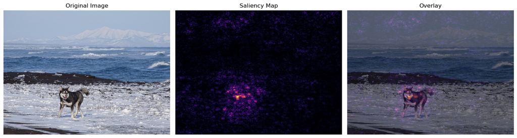

```python
# -----------------------------
# Run example
# -----------------------------
def saliency_demo(img_path):
    model = models.resnet50(pretrained=True)
    img, input_tensor = preprocess_image(img_path)
    saliency_map, class_idx = compute_saliency(model, input_tensor)
    show_saliency(img, saliency_map)

# Example usage
saliency_demo("image.jpg")
```

## **References**

[TensorFlow: Advanced Techniques Specialization](https://www.coursera.org/specializations/tensorflow-advanced-techniques)